# Reproducible Research - Week 2 - Course Project 1

##Loading and preprocessing the data

#Load Data

```r
activity <- read.csv("C:/Users/A42512/Documents/1-1/Training/Data Science Foundations using R Specialization/Part 5 - Reproducible Research/Course Project 1/activity.csv")
```

##What is mean total number of steps taken per day?

#1. Calculate the total number of steps taken per day

```r
TotalStepsPerDay <- aggregate(activity$steps, by=list(date=activity$date), FUN=sum)
TotalStepsPerDay
```

```
##          date     x
## 1  2012-10-01    NA
## 2  2012-10-02   126
## 3  2012-10-03 11352
## 4  2012-10-04 12116
## 5  2012-10-05 13294
## 6  2012-10-06 15420
## 7  2012-10-07 11015
## 8  2012-10-08    NA
## 9  2012-10-09 12811
## 10 2012-10-10  9900
## 11 2012-10-11 10304
## 12 2012-10-12 17382
## 13 2012-10-13 12426
## 14 2012-10-14 15098
```

[output cut: 47 more lines]

#2. If you do not understand the difference between a histogram and a barplot, research the difference between them. Make a histogram of the total number of steps taken each day

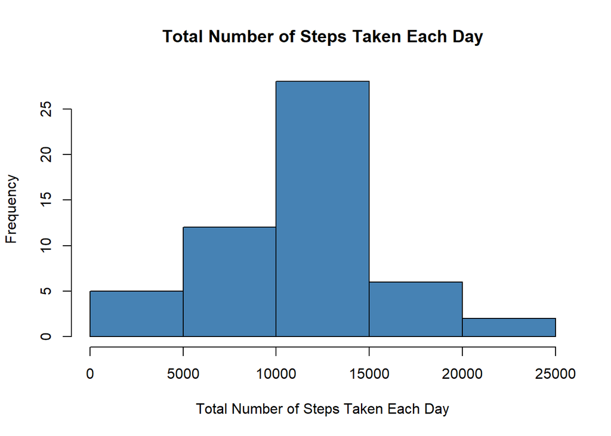

```r
hist(TotalStepsPerDay$x, col= "steel blue", main = "Total Number of Steps Taken Each Day",  xlab = "Total Number of Steps Taken Each Day")
```

#3. Calculate and report the mean and median of the total number of steps taken per day

```r
MeanTotalNumberOfStepsTakenPerDay <- mean(TotalStepsPerDay$x, na.rm = TRUE) #remove NAs
MeanTotalNumberOfStepsTakenPerDay
```

```
## [1] 10766.19
```

```r
MedianTotalNumberOfStepsTakenPerDay <- median(TotalStepsPerDay$x, na.rm = TRUE) #remove NAs
MedianTotalNumberOfStepsTakenPerDay
```

```
## [1] 10765
```

##What is the average daily activity pattern?

#1. Make a time series plot (i.e. type = “l”) of the 5-minute interval (x-axis) and the average number of steps taken, averaged across all days (y-axis)

```r
AvgStepsPerInterval <- aggregate(activity$steps, list(interval=activity$interval), FUN=mean, na.rm = TRUE)
AvgStepsPerInterval
```

```
##     interval           x
## 1          0   1.7169811
## 2          5   0.3396226
## 3         10   0.1320755
## 4         15   0.1509434
## 5         20   0.0754717
## 6         25   2.0943396
## 7         30   0.5283019
## 8         35   0.8679245
## 9         40   0.0000000
## 10        45   1.4716981
## 11        50   0.3018868
## 12        55   0.1320755
## 13       100   0.3207547
## 14       105   0.6792453
```

[output cut: 274 more lines]

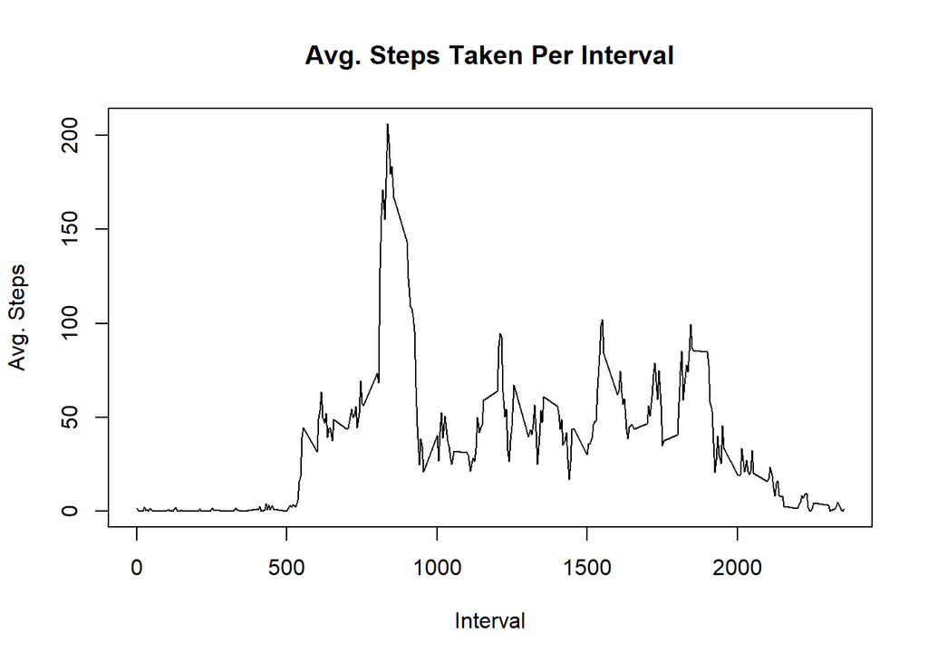

```r
plot(AvgStepsPerInterval$interval, AvgStepsPerInterval$x, type = "l", xlab = "Interval", ylab = "Avg. Steps", main = "Avg. Steps Taken Per Interval")
```

#2. Which 5-minute interval, on average across all the days in the dataset, contains the maximum number of steps?

```r
OrderedAvgStepsPerInterval <- AvgStepsPerInterval[order(AvgStepsPerInterval$x),]
IntervalWithMaxSteps <- tail(OrderedAvgStepsPerInterval$interval,1)
IntervalWithMaxSteps
```

```
## [1] 835
```

##Imputing missing values

Note that there are a number of days/intervals where there are missing values (coded as NA). The presence of missing days may introduce bias into some calculations or summaries of the data.

#1. Calculate and report the total number of missing values in the dataset (i.e. the total number of rows with NAs)

```r
TotalNumberOfRowsWithNAs <- sum(!complete.cases(activity))
TotalNumberOfRowsWithNAs
```

```
## [1] 2304
```

#2. Devise a strategy for filling in all of the missing values in the dataset. The strategy does not need to be sophisticated. For example, you could use the mean/median for that day, or the mean for that 5-minute interval, etc.

The strategy for missing steps values will be to use the mean for the interval.

#3. Create a new dataset that is equal to the original dataset but with the missing data filled in.

```r
activity2 <- merge(activity, AvgStepsPerInterval, by = "interval") #merge data to get the corresponding avg. interval value
library(dplyr) #load dplyr
activity3 <- activity2 %>% mutate(steps = coalesce(steps, x)) #if steps is NA, then use the avg interval value
activity4 <- select(activity3, interval, steps, date) #select only columns needed
activity4
```

```
##       interval       steps       date
## 1            0   1.7169811 2012-10-01
## 2            0   0.0000000 2012-11-23
## 3            0   0.0000000 2012-10-28
## 4            0   0.0000000 2012-11-06
## 5            0   0.0000000 2012-11-24
## 6            0   0.0000000 2012-11-15
## 7            0   0.0000000 2012-10-20
## 8            0   0.0000000 2012-11-16
## 9            0   0.0000000 2012-11-07
## 10           0   0.0000000 2012-11-25
## 11           0   1.7169811 2012-11-04
## 12           0   0.0000000 2012-11-08
## 13           0   0.0000000 2012-10-12
## 14           0   0.0000000 2012-10-30
```

[output cut: 17554 more lines]

#4. Make a histogram of the total number of steps taken each day and Calculate and report the mean and median total number of steps taken per day. Do these values differ from the estimates from the first part of the assignment? What is the impact of imputing missing data on the estimates of the total daily number of steps?

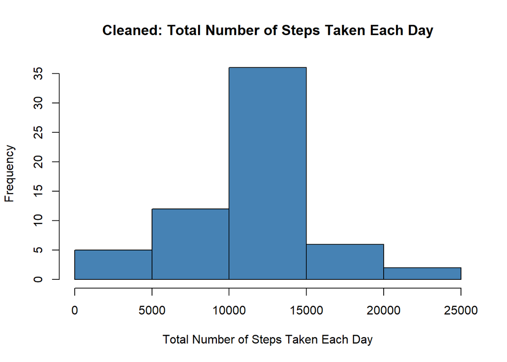

```r
#histogram
CleanedTotalStepsPerDay <- aggregate(activity4$steps, by=list(date=activity4$date), FUN=sum)
hist(CleanedTotalStepsPerDay$x, col= "steel blue", main = "Cleaned: Total Number of Steps Taken Each Day",  xlab = "Total Number of Steps Taken Each Day")
```

```r
#mean
CleanedMeanTotalNumberOfStepsTakenPerDay <- mean(CleanedTotalStepsPerDay$x)
CleanedMeanTotalNumberOfStepsTakenPerDay
```

```
## [1] 10766.19
```

```r
#median
CleanedMedianTotalNumberOfStepsTakenPerDay <- median(CleanedTotalStepsPerDay$x)
CleanedMedianTotalNumberOfStepsTakenPerDay
```

```
## [1] 10766.19
```

When you use the data with no missing steps values, the “total number” increases because now there are additional values being factored into the total vs. nothing, the mean is the same because it was ignoring the NAs before but now the missing values are the mean so it is the same, the median increased slightly because there are more values now whereas before the NAs were being ignored.

##Are there differances in activity patterns between weekdays and weekends?

For this part the weekdays() function may be of some help here. Use the dataset with the filled-in missing values for this part.

#1. Create a new factor variable in the dataset with two levels – “weekday” and “weekend” indicating whether a given date is a weekday or weekend day.

```r
activity4$date <- as.Date(activity4$date, format = "%Y-%m-%d") #convert to actual date data type
activity4$Day <- weekdays(activity4$date) #get the day of week of the date
activity5 <- activity4 %>% mutate(
  DayType = case_when(
  Day == "Saturday" ~ "weekend",
  Day == "Sunday" ~ "weekend",
  TRUE ~ "weekday"
))
activity5
```

```
##       interval       steps       date       Day DayType
## 1            0   1.7169811 2012-10-01    Monday weekday
## 2            0   0.0000000 2012-11-23    Friday weekday
## 3            0   0.0000000 2012-10-28    Sunday weekend
## 4            0   0.0000000 2012-11-06   Tuesday weekday
## 5            0   0.0000000 2012-11-24  Saturday weekend
## 6            0   0.0000000 2012-11-15  Thursday weekday
## 7            0   0.0000000 2012-10-20  Saturday weekend
## 8            0   0.0000000 2012-11-16    Friday weekday
## 9            0   0.0000000 2012-11-07 Wednesday weekday
## 10           0   0.0000000 2012-11-25    Sunday weekend
## 11           0   1.7169811 2012-11-04    Sunday weekend
## 12           0   0.0000000 2012-11-08  Thursday weekday
## 13           0   0.0000000 2012-10-12    Friday weekday
## 14           0   0.0000000 2012-10-30   Tuesday weekday
```

[output cut: 17554 more lines]

#2. Make a panel plot containing a time series plot (i.e. type = “l”) of the 5-minute interval (x-axis) and the average number of steps taken, averaged across all weekday days or weekend days (y-axis). See the README file in the GitHub repository to see an example of what this plot should look like using simulated data.

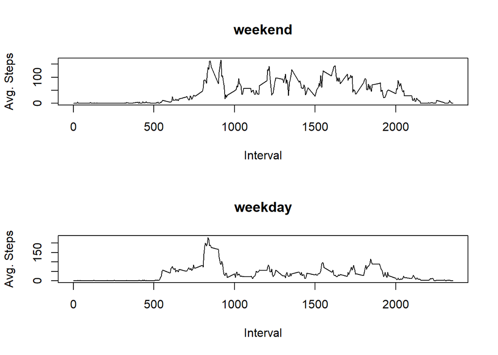

```r
#weekday
WeekdaySteps <- filter(activity5, activity5$DayType == "weekday")
WeekdayAvgStepsPerInterval <- aggregate(WeekdaySteps$steps, list(interval=WeekdaySteps$interval), FUN=mean, na.rm = TRUE)

#weekend
WeekendSteps <- filter(activity5, activity5$DayType == "weekend")
WeekendAvgStepsPerInterval <- aggregate(WeekendSteps$steps, list(interval=WeekendSteps$interval), FUN=mean, na.rm = TRUE)

#panel plot
par(mfrow = c(2,1))
plot(WeekendAvgStepsPerInterval$interval, WeekendAvgStepsPerInterval$x, type = "l", main = "weekend", xlab = "Interval", ylab= "Avg. Steps")
plot(WeekdayAvgStepsPerInterval$interval, WeekdayAvgStepsPerInterval$x, type = "l", main = "weekday", xlab = "Interval", ylab = "Avg. Steps")
```